# DATA606_FALL_2018_FINAL_PROJECT_PROPOSAL

John K. Hancock

October 29, 2018

# DATA606 Fall 2018 - FINAL PROJECT

# Pitching and Wins

## I. Introduction

In the game of baseball, there’s a heuristic that pitching wins games and matters more than hitting and scoring. In a blog article titled, Hitting or Pitching,Which wins more games, www.wmbriggs.com/post/120/, by Tim Murray and William Briggs (April 28, 2008), they explore which is a better predictor of wins, hitting or pitching. For this project, I took a slightly different appoach. I wanted to see whether pitching alone is a good predictor of wins.

## II. Data

The data was collected from the website, fangraphs.com. Fangraphs is operated by FanGraphs, Inc. Fangraphs compiles historical statistical data for the entire history of Major League Baseball (“MLB”). In addition, it creates and records advanced baseball metrics outside of the established statistics. FanGraphs is well established as a chronicler and compiler of baseball statistics. It has parternership deals with ESPN and SB Nation. Fangraphs has an interface for members (of which I am one) where you are able to download individual and team statistics covering a single season or multiple years. For this project, I downloaded data for all 30 teams from 1998 to 2017. I purposely chose the year 1998 as that was the last year that MLB expanded its number of teams.On the site, you can generate a custom report for pitching statistics which is how I collected the data.

I combined the downloads into one csv file which is located in the DATA folder. The file is titled: DATA/MLB_PITCHING_STATS_1998_to_2017.csv

## III. Exploratory Data Analysis

```r
mlb_df <- read.csv('DATA/MLB_PITCHING_STATS_1998_to_2017.csv')
```

```r
dim(mlb_df)
```

```
## [1] 600  22
```

There are 600 observations and 22 variables. Each observation represents the win total and key pitching statistics for 30 MLB teams from 1998 to 2017.

### Description of Variables

The table below provides descriptions for all 22 variables.

| Variables | Description |
| --- | --- |
| Team | Name of the MLB Team |
| W | Number of Wins |
| ERA | Team Earned Run Average |
| H | Number of Hits Allowed by Team |
| R | Number of Runs Allowed by Team |
| ER | Earned Runs Allowed by Team |
| HR | Home Runs Allowed by Team |
| BB | Walks Allowed by Team |
| SO | Strikeouts by Team |
| KsPer9 | Number of Strikeouts per 9 innings |
| BBper9 | Number of Walks per 9 innings |
| KperBB | Strikeouts per Walks |
| Hper9 | Hits allowed per 9 innings |
| HRper9 | Home Runs per 9 innings |
| AVG | Batting average allowed by Team |
| WHIP | Walks plus Hits per innings pitched |
| BABIP | The rate at which the pitcher allows a hit when the ball is put in play, calculated as (H-HR)/(AB-K-HR+SF) |
| LOB_pct | Percentage of pitcher?s own base runners that they strand over the course of a season Not equal to the LOB column in the box score |
| FIP | An estimate of a pitcher?s ERA based on strikeouts, walks/HBP, and home runs allowed, assuming league average results on balls in play |
| RAR | Runs above replacement level The number of runs a player has been worth to his team compared to a freely available player based on FIP |
| K_pct | Frequency with which the pitcher has struck out a batter, calculated as strikeouts divided by total batters faced |
| BB_pct | Frequency with which the pitcher has issued a walk, calculated as walks divided by total batters faced |

### Scaling the Data

```r
head(mlb_df, 10)
```

```
##         Team   W  ERA    H   R  ER  HR  BB   SO KsPer9 BBper9 KperBB Hper9
## 1     Braves 106 3.25 1291 581 520 117 467 1232   7.71   2.92   2.64  8.08
## 2     Astros 102 3.50 1435 620 572 147 465 1187   7.26   2.84   2.55  8.78
## 3     Padres  98 3.63 1384 635 587 139 501 1217   7.53   3.10   2.43  8.56
## 4       Mets  88 3.77 1381 645 611 152 532 1129   6.97   3.28   2.12  8.52
## 5    Dodgers  83 3.81 1332 678 612 135 587 1178   7.33   3.65   2.01  8.28
## 6    Yankees 114 3.82 1357 656 619 156 466 1080   6.67   2.88   2.32  8.38
## 7    Pirates  69 3.91 1433 718 629 147 530 1112   6.91   3.29   2.10  8.90
## 8     Giants  89 4.19 1457 739 687 171 562 1089   6.64   3.42   1.94  8.88
## 9    Red Sox  92 4.19 1406 729 668 168 504 1025   6.42   3.16   2.03  8.81
## 10 Blue Jays  88 4.29 1443 768 698 169 587 1154   7.09   3.61   1.97  8.86
##    HRper9   AVG WHIP BABIP LOB_pct  FIP   RAR K_pct BB_pct
## 1    0.73 0.236 1.22 0.285    0.74 3.53 255.7 0.207   0.08
## 2    0.90 0.251 1.29 0.295    0.76 3.86 178.7 0.191   0.08
## 3    0.86 0.247 1.30 0.293    0.75 3.84 202.1 0.198   0.08
## 4    0.94 0.248 1.31 0.287    0.76 4.18 143.8 0.183   0.09
## 5    0.84 0.241 1.33 0.284    0.73 4.06 171.8 0.191   0.10
## 6    0.96 0.244 1.25 0.277    0.74 4.15 212.5 0.177   0.08
## 7    0.91 0.253 1.35 0.292    0.71 4.08 172.4 0.179   0.09
## 8    1.04 0.253 1.37 0.287    0.73 4.42 120.3 0.171   0.09
## 9    1.05 0.252 1.33 0.282    0.71 4.40 156.7 0.167   0.08
## 10   1.04 0.252 1.39 0.290    0.71 4.36 181.2 0.182   0.09
```

Looking at the first 10 records from the load, you can see that the numerical data is on different scales. For example, Hits allowed (“H”) is an integer value, but K_pct is a percentage. From the MiniTab blog post, “When Is It Crucial to Standardize the Variables in a Regression Model?” (02/10/2016):

“You should standardize the variables when your regression model contains polynomial terms or interaction terms. While these types of terms can provide extremely important information about the relationship between the response and predictor variables, they also produce excessive amounts of multicollinearity.

Multicollinearity is a problem because it can hide statistically significant terms, cause the coefficients to switch signs, and make it more difficult to specify the correct model.

Your regression model almost certainly has an excessive amount of multicollinearity if it contains polynomial or interaction terms. Fortunately, standardizing the predictors is an easy way to reduce multicollinearity and the associated problems that are caused by these higher-order terms. If you don’t standardize the variables when your model contains these types of terms, you are at risk of both missing statistically significant results and producing misleading results."

(MiniTab)[http://blog.minitab.com/blog/adventures-in-statistics-2/when-is-it-crucial-to-standardize-the-variables-in-a-regression-model]

```r
#mlb_df[,3:22] <- t(apply(mlb_df[,3:22], 1, rescale))
#head(mlb_df,10)
```

## IV. Creating Categorical Varibles

### Record Category

Looking at the distribution for wins, you can see that Wins are normally distributed.

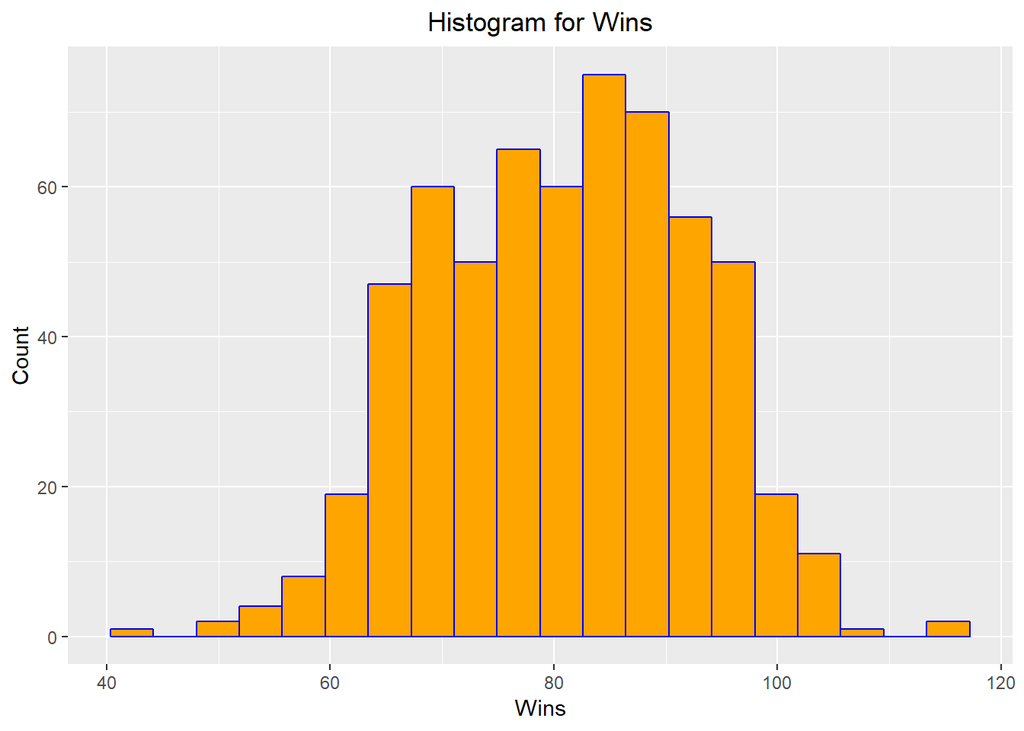

```r
ggplot(mlb_df, aes(x=W)) + geom_histogram(bins=20,
                 col="blue",
                 fill="orange") + labs(title="Histogram for Wins", align="center") +
                                  labs(x="Wins", y="Count")
```

For a MLB team, winning 100 games in a season is a high water mark. It is considered a high accomplishment. Over the past 20 years prior to 2018, only 24 times (4%) has a team won 100 games or more.

```r
one_hundred_wins <- nrow(mlb_df[mlb_df$W >= 100,])
one_hundred_wins
```

```
## [1] 24
```

```r
one_hundred_wins / nrow(mlb_df)
```

```
## [1] 0.04
```

I created a new variable called “Record” which catgorizes the win totals by levels

1. 100 wins or more
2. Above .500 and Less than 100 wins
3. Below .500 but above 50 wins
4. Less than 50 wins

```r
mlb_df[mlb_df$W >= 100, "Record"] <- "100 wins or Above"
mlb_df[mlb_df$W >= 82  & mlb_df$W < 100, "Record"] <- "Above .500 and Less than 100 Wins"
mlb_df[mlb_df$W < 82 & mlb_df$W > 50, "Record"] <- "Below .500 but above 50 wins"
mlb_df[mlb_df$W <= 50, "Record"] <- "Less than 50 wins"
mlb_df$Record <- as.factor(mlb_df$Record)
```

### League Category

MLB is an unusual sport in that it consists of two different leagues, the American and National leagues (“AL” and “NL”), that play under different rules. In the National league, the pitcher, typically the worst hitter, has to bat. In the American league, teams are allowed a Designated Hitter.

In short, one league has the potential for more offense, AL, than the other, and this impacts pitching as NL pitchers typically have lower ERAs. For the model, I have to distinguish between the two leagues. To do so, I created the category variable, “League”, and assigned the corresponding league to each team.

```r
mlb_df$League <- case_when(mlb_df$Team == 'Braves'~'National League',
 mlb_df$Team == 'Marlins'~'National League',
 mlb_df$Team == 'Mets'~'National League',
 mlb_df$Team == 'Phillies'~'National League',
 mlb_df$Team == 'Nationals'~'National League',
 mlb_df$Team == 'Cubs'~'National League',
 mlb_df$Team == 'Reds'~'National League',
 mlb_df$Team == 'Brewers'~'National League',
 mlb_df$Team == 'Pirates'~'National League',
 mlb_df$Team == 'Cardinals'~'National League',
 mlb_df$Team == 'iamondbacks'~'National League',
 mlb_df$Team == 'Rockies'~'National League',
 mlb_df$Team == 'Dodgers'~'National League',
 mlb_df$Team == 'Padres'~'National League',
 mlb_df$Team == 'Giants'~'National League',
 TRUE ~ as.character('American League'))
```

```r
rows <- as.numeric(row.names.data.frame(mlb_df[mlb_df$Team == 'Astros',]))
rows <- rows[rows < 480]
mlb_df$League[ rows] <- "National League"
```

```r
mlb_df[mlb_df$Team == 'Astros', ]
```

```
##       Team   W  ERA    H   R  ER  HR  BB   SO KsPer9 BBper9 KperBB Hper9
## 2   Astros 102 3.50 1435 620 572 147 465 1187   7.26   2.84   2.55  8.78
## 33  Astros  97 3.84 1485 675 622 128 478 1204   7.43   2.95   2.52  9.16
## 88  Astros  72 5.42 1596 944 865 234 598 1064   6.66   3.74   1.78  9.99
## 106 Astros  93 4.39 1453 769 709 221 486 1228   7.60   3.01   2.53  8.99
## 132 Astros  84 4.00 1423 695 643 151 546 1219   7.59   3.40   2.23  8.86
## 157 Astros  87 3.87 1350 677 623 161 565 1139   7.07   3.51   2.02  8.38
## 187 Astros  92 4.05 1416 698 650 174 525 1282   8.00   3.27   2.44  8.83
## 212 Astros  89 3.52 1336 609 564 155 440 1164   7.26   2.74   2.65  8.33
## 245 Astros  82 4.09 1425 719 668 182 480 1160   7.11   2.94   2.42  8.73
## 291 Astros  73 4.70 1566 813 765 206 510 1109   6.81   3.13   2.17  9.62
## 317 Astros  86 4.39 1453 743 695 197 492 1095   6.91   3.11   2.23  9.17
## 354 Astros  74 4.54 1521 770 722 176 546 1144   7.20   3.44   2.10  9.57
## 376 Astros  76 4.09 1446 729 654 140 548 1210   7.57   3.43   2.21  9.04
## 418 Astros  56 4.51 1477 796 719 188 560 1191   7.47   3.51   2.13  9.26
```

[output cut: 48 more lines]

```r
mlb_df$League <- as.factor(mlb_df$League)
```

### Research question

Does a mlb team’s key pitching statistics predict their win totals? If so, which pitching metric, ERA, Strikeouts, WHIP, or FIP provide the best predictor for wins?

### Data Collection

Data was collected from the website FanGraphs.com. For the purpose of this academic exercise, I purchased a year’s membership to the site and I was able to download the datasets needed for this project.

### Data Source

Fangraphs.com is website operated by FanGraphs, Inc. Fangraphs compiles historical statistical data for the entire history of Major League Baseball. In addition, it creates and records advanced baseball metrics outside of the established statistics. FanGraphs is well established as a chronicler and compiler of baseball statistics. It has parternership deals with ESPN and SB Nation. Link to website: [FanGraphs.com](https://www.fangraphs.com/) [Wikipedia](https://en.wikipedia.org/wiki/Fangraphs)

### Dependent Variable

There are two response variables. One is Wins which is numeric (quantative variable), and the other is Record which is qualitative.

### Independent Variable

The independent variables are ERA, Strikeouts(“SO”), Walks, Hits to Innings Pitched (“WHIP), Fielded Independent Pitching (”FIP“) which are all numeric. The qualitative variable is League.

```r
describe(mlb_df$ERA)
```

```
## mlb_df$ERA
##        n  missing distinct     Info     Mean      Gmd      .05      .10
##      600        0      205        1     4.28   0.6167     3.43     3.58
##      .25      .50      .75      .90      .95
##     3.89     4.24     4.66     5.01     5.20
##
## lowest : 2.94 3.02 3.03 3.13 3.15, highest: 5.56 5.67 5.69 5.71 6.03
```

```r
describe(mlb_df$SO)
```

```
## mlb_df$SO
##        n  missing distinct     Info     Mean      Gmd      .05      .10
##      600        0      363        1     1129      157      926      958
##      .25      .50      .75      .90      .95
##     1025     1120     1221     1311     1372
##
## lowest :  764  794  831  846  859, highest: 1549 1560 1580 1593 1614
```

```r
describe(mlb_df$WHIP)
```

```
## mlb_df$WHIP
##        n  missing distinct     Info     Mean      Gmd      .05      .10
##      600        0       51    0.999    1.368   0.1096     1.22     1.24
##      .25      .50      .75      .90      .95
##     1.30     1.36     1.44     1.50     1.53
##
## lowest : 1.11 1.14 1.15 1.16 1.17, highest: 1.60 1.61 1.62 1.64 1.71
```

```r
describe(mlb_df$FIP)
```

```
## mlb_df$FIP
##        n  missing distinct     Info     Mean      Gmd      .05      .10
##      600        0      179        1    4.279   0.4915    3.580    3.729
##      .25      .50      .75      .90      .95
##    3.970    4.280    4.570    4.841    5.010
##
## lowest : 3.18 3.24 3.27 3.30 3.33, highest: 5.29 5.31 5.46 5.52 5.54
```

```r
table(mlb_df$Record, useNA='ifany')
```

```
##
##                 100 wins or Above Above .500 and Less than 100 Wins
##                                24                               270
##      Below .500 but above 50 wins                 Less than 50 wins
##                               305                                 1
```

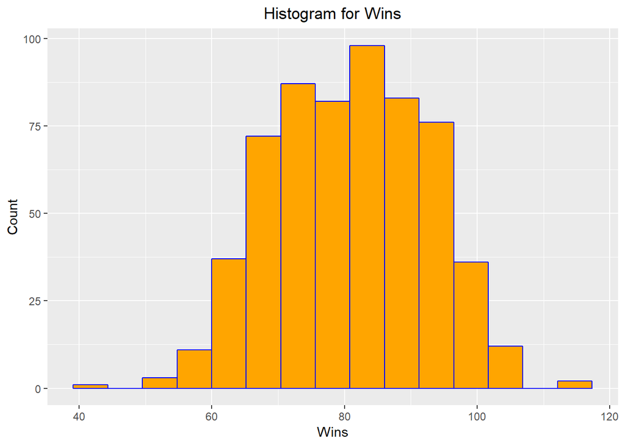

```r
ggplot(mlb_df, aes(x=W)) + geom_histogram(bins=15,
                 col="blue",
                 fill="orange") + labs(title="Histogram for Wins", align="center") +
                                  labs(x="Wins", y="Count")
```

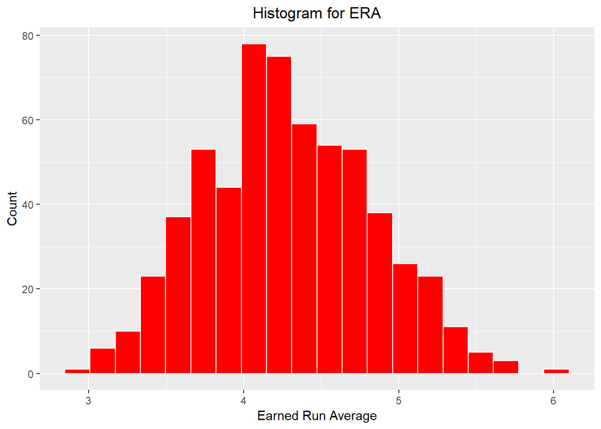

```r
ggplot(mlb_df, aes(x=ERA)) + geom_histogram(bins=20,
                 col="white",
                 fill="red") + labs(title="Histogram for ERA") +
                                  labs(x="Earned Run Average", y="Count")
```

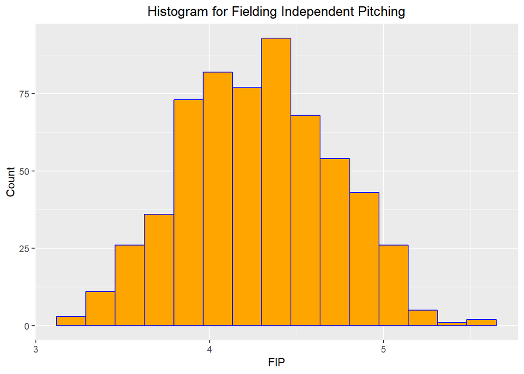

```r
ggplot(mlb_df, aes(x=FIP)) + geom_histogram(bins=15,
                 col="blue",
                 fill="orange") + labs(title="Histogram for Fielding Independent Pitching") +
                                    labs(x="FIP", y="Count")
```